# Data Analysis on Predict test scores of students

### Bar plot

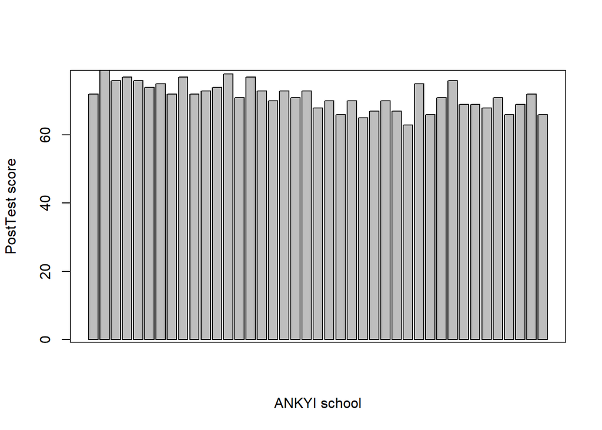

```r
barplot(temp$posttest)
title(xlab = 'ANKYI school', ylab = 'PostTest score')
box()
```

### table() used to get the column’s diff level(type) counts

```r
table(df$school)
```

```
##
## ANKYI CCAAW CIMBB CUQAM DNQDD FBUMG GJJHK GOKXL GOOBU IDGFP KFZMY KZKKE LAYPA
##    41   109    74   107   122    46   118    64   158    94    52   111    57
## OJOBU QOQTS UAGPU UKPGS UUUQX VHDHF VKWQH VVTVA ZMNYA ZOWMK
##    81   149    87   128    84    51   100   114    69   117
```

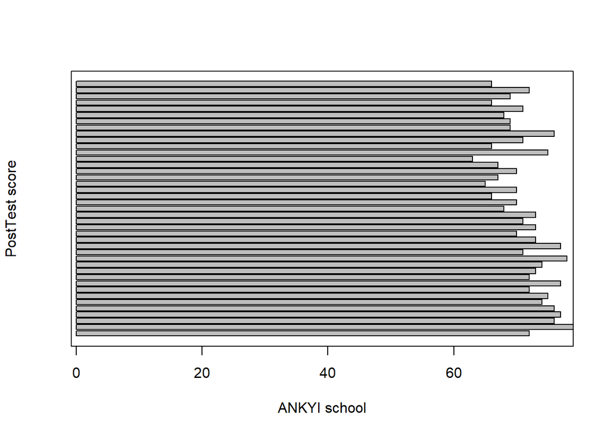

```r
barplot(temp$posttest, horiz = T)
title(xlab = 'ANKYI school', ylab = 'PostTest score')
box()
```

### the analysis of variance using the aov() command

```r
temp.aov = na.omit(aov(temp$pretest ~ temp$posttest, data = temp))
temp.aov
```

```
## Call:
##    aov(formula = temp$pretest ~ temp$posttest, data = temp)
##
## Terms:
##                 temp$posttest Residuals
## Sum of Squares       200.8709  168.3486
## Deg. of Freedom             1        39
##
## Residual standard error: 2.07765
## Estimated effects may be unbalanced
```

### To see the classic ANOVA table of results you need to use the summary() command like so

```r
summary(temp.aov)
```

```
##               Df Sum Sq Mean Sq F value   Pr(>F)
## temp$posttest  1  200.9  200.87   46.53 3.77e-08 ***
## Residuals     39  168.3    4.32
## ---
## Signif. codes:  0 '***' 0.001 '**' 0.01 '*' 0.05 '.' 0.1 ' ' 1
```

### Two-way ANOVA

```r
toway = aov(posttest ~ pretest * n_student, data = temp)
toway
```

```
## Call:
##    aov(formula = posttest ~ pretest * n_student, data = temp)
##
## Terms:
##                  pretest n_student pretest:n_student Residuals
## Sum of Squares  340.4376   36.3381            0.2261  248.7543
## Deg. of Freedom        1         1                 1        37
##
## Residual standard error: 2.592892
## Estimated effects may be unbalanced
```

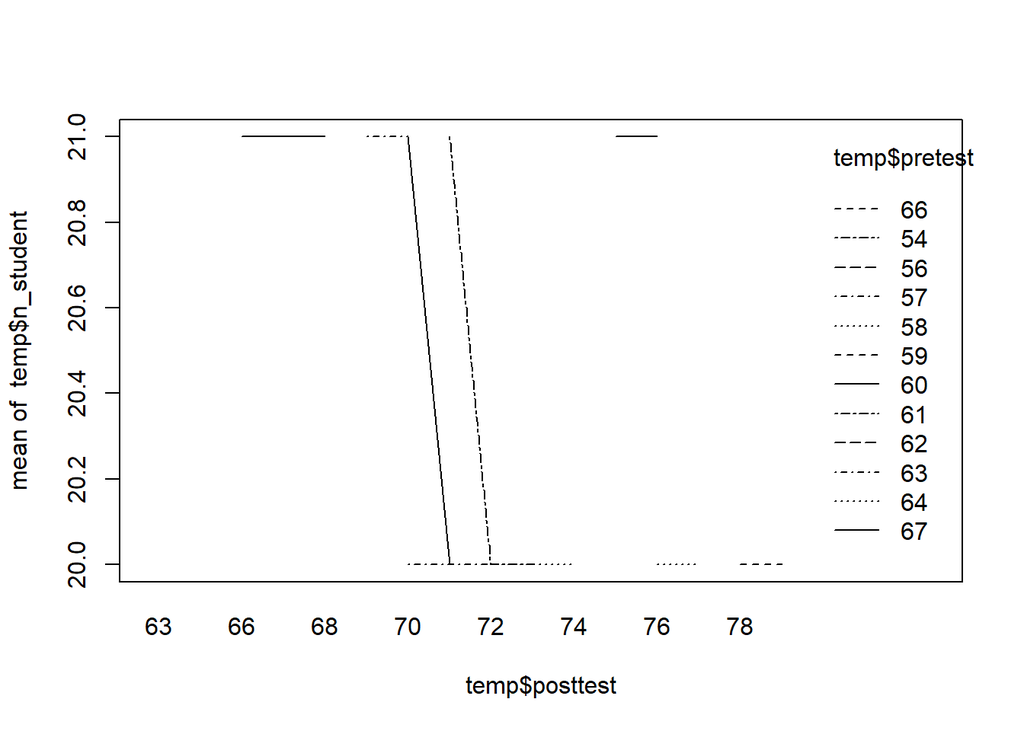

```r
interaction.plot(temp$posttest, temp$pretest, temp$n_student)
```

```r
factor(df$school_setting)
```

```
##    [1] Urban    Urban    Urban    Urban    Urban    Urban    Urban    Urban
##    [9] Urban    Urban    Urban    Urban    Urban    Urban    Urban    Urban
##   [17] Urban    Urban    Urban    Urban    Urban    Urban    Urban    Urban
##   [25] Urban    Urban    Urban    Urban    Urban    Urban    Urban    Urban
##   [33] Urban    Urban    Urban    Urban    Urban    Urban    Urban    Urban
##   [41] Urban    Suburban Suburban Suburban Suburban Suburban Suburban Suburban
##   [49] Suburban Suburban Suburban Suburban Suburban Suburban Suburban Suburban
##   [57] Suburban Suburban Suburban Suburban Suburban Suburban Suburban Suburban
##   [65] Suburban Suburban Suburban Suburban Suburban Suburban Suburban Suburban
##   [73] Suburban Suburban Suburban Suburban Suburban Suburban Suburban Suburban
##   [81] Suburban Suburban Suburban Suburban Suburban Suburban Suburban Suburban
##   [89] Suburban Suburban Suburban Suburban Suburban Suburban Suburban Suburban
##   [97] Suburban Suburban Suburban Suburban Suburban Suburban Suburban Suburban
##  [105] Suburban Suburban Suburban Suburban Suburban Suburban Suburban Suburban
##  [113] Suburban Suburban Suburban Suburban Suburban Suburban Suburban Suburban
```

[output cut: 253 more lines]

### creating new testCol/testRow for addition as a new column/row to the df object (using rep() command)

```r
testCol = c(rep(df$posttest - df$pretest, length(df)))
head(testCol)
```

```
## [1] 10 13 12 16 12  8
```

```r
testRow = c('NMIT', 'Urban', "Non-public", 263, 'Standard', 18, '1NT20SDS09', 'Male', 'NA', 00, 00)
testRow
```

```
##  [1] "NMIT"       "Urban"      "Non-public" "263"        "Standard"
##  [6] "18"         "1NT20SDS09" "Male"       "NA"         "0"
## [11] "0"
```

### Adding Rows or Columns

```r
test = data.frame(df, testCol)
head(test)
```

```
##   school school_setting school_type classroom teaching_method n_student
## 1  ANKYI          Urban  Non-public       6OL        Standard        20
## 2  ANKYI          Urban  Non-public       6OL        Standard        20
## 3  ANKYI          Urban  Non-public       6OL        Standard        20
## 4  ANKYI          Urban  Non-public       6OL        Standard        20
## 5  ANKYI          Urban  Non-public       6OL        Standard        20
## 6  ANKYI          Urban  Non-public       6OL        Standard        20
##   student_id gender            lunch pretest posttest testCol
## 1      2FHT3 Female Does not qualify      62       72      10
## 2      3JIVH Female Does not qualify      66       79      13
## 3      3XOWE   Male Does not qualify      64       76      12
## 4      556O0 Female Does not qualify      61       77      16
## 5      74LOE   Male Does not qualify      64       76      12
## 6      7YZO8 Female Does not qualify      66       74       8
```

```r
test = df
test['testRow',] = testRow
tail(test)
```

```
##         school school_setting school_type classroom teaching_method n_student
## 2129     ZOWMK          Urban      Public       ZBH        Standard        30
## 2130     ZOWMK          Urban      Public       ZBH        Standard        30
## 2131     ZOWMK          Urban      Public       ZBH        Standard        30
## 2132     ZOWMK          Urban      Public       ZBH        Standard        30
## 2133     ZOWMK          Urban      Public       ZBH        Standard        30
## testRow   NMIT          Urban  Non-public       263        Standard        18
##         student_id gender                            lunch pretest posttest
## 2129         T8LSK Female                 Does not qualify      39       55
## 2130         VNP26 Female Qualifies for reduced/free lunch      38       46
## 2131         YDR1Z Female Qualifies for reduced/free lunch      45       51
## 2132         YUEIH   Male Qualifies for reduced/free lunch      46       53
## 2133         ZVCQ8   Male Qualifies for reduced/free lunch      41       48
## testRow 1NT20SDS09   Male                               NA       0        0
```

```r
test = df
test["Test",] = NA
tail(test)
```

```
##      school school_setting school_type classroom teaching_method n_student
## 2129  ZOWMK          Urban      Public       ZBH        Standard        30
## 2130  ZOWMK          Urban      Public       ZBH        Standard        30
## 2131  ZOWMK          Urban      Public       ZBH        Standard        30
## 2132  ZOWMK          Urban      Public       ZBH        Standard        30
## 2133  ZOWMK          Urban      Public       ZBH        Standard        30
## Test   <NA>           <NA>        <NA>      <NA>            <NA>        NA
##      student_id gender                            lunch pretest posttest
## 2129      T8LSK Female                 Does not qualify      39       55
## 2130      VNP26 Female Qualifies for reduced/free lunch      38       46
## 2131      YDR1Z Female Qualifies for reduced/free lunch      45       51
## 2132      YUEIH   Male Qualifies for reduced/free lunch      46       53
## 2133      ZVCQ8   Male Qualifies for reduced/free lunch      41       48
## Test       <NA>   <NA>                             <NA>      NA       NA
```

### Column Indexes

```r
col(temp, as.factor = F)
```

```
##       [,1] [,2] [,3] [,4] [,5] [,6] [,7] [,8] [,9] [,10] [,11]
##  [1,]    1    2    3    4    5    6    7    8    9    10    11
##  [2,]    1    2    3    4    5    6    7    8    9    10    11
##  [3,]    1    2    3    4    5    6    7    8    9    10    11
##  [4,]    1    2    3    4    5    6    7    8    9    10    11
##  [5,]    1    2    3    4    5    6    7    8    9    10    11
##  [6,]    1    2    3    4    5    6    7    8    9    10    11
##  [7,]    1    2    3    4    5    6    7    8    9    10    11
##  [8,]    1    2    3    4    5    6    7    8    9    10    11
##  [9,]    1    2    3    4    5    6    7    8    9    10    11
## [10,]    1    2    3    4    5    6    7    8    9    10    11
## [11,]    1    2    3    4    5    6    7    8    9    10    11
## [12,]    1    2    3    4    5    6    7    8    9    10    11
## [13,]    1    2    3    4    5    6    7    8    9    10    11
## [14,]    1    2    3    4    5    6    7    8    9    10    11
```

[output cut: 27 more lines]

### Extracting two(2) columns from df

```r
x = df[ , 10:11]
head(x)
```

```
##   pretest posttest
## 1      62       72
## 2      66       79
## 3      64       76
## 4      61       77
## 5      64       76
## 6      66       74
```

### Simple Column and Row Summaries

```r
colMeans(x)
```

```
##  pretest posttest
## 54.95593 67.10220
```

```r
rowMeans(x)
```

```
##    [1] 67.0 72.5 70.0 69.0 70.0 70.0 69.0 67.5 70.5 66.5 67.0 69.0 72.0 65.5
##   [15] 70.5 68.5 66.5 70.0 67.0 68.5 64.0 65.0 61.5 63.5 60.5 62.5 65.0 63.5
##   [29] 58.5 67.5 62.0 68.5 68.0 64.0 63.0 64.0 66.0 63.5 64.0 67.0 63.0 68.0
##   [43] 68.0 73.0 67.5 76.0 72.5 68.5 65.5 66.5 66.5 69.5 70.5 68.0 69.0 63.5
##   [57] 74.5 74.0 73.5 71.5 73.0 74.0 75.5 75.0 79.0 77.5 80.5 79.5 73.5 70.0
##   [71] 80.0 79.5 76.0 72.5 75.0 74.0 74.0 70.5 76.0 72.0 76.5 73.0 67.5 70.0
##   [85] 72.0 75.0 69.0 71.5 70.0 66.5 71.5 71.0 68.0 67.0 72.0 78.0 68.0 75.5
##   [99] 79.0 81.0 73.5 77.0 77.0 76.5 75.0 78.0 76.5 81.0 76.5 78.0 77.0 74.5
##  [113] 80.5 77.5 77.0 58.5 62.5 66.5 66.0 64.5 62.0 63.0 65.0 61.0 59.0 69.0
##  [127] 66.5 60.5 63.0 61.0 64.5 72.0 73.5 71.5 74.0 65.0 65.5 69.0 72.5 68.5
##  [141] 79.0 71.5 68.5 71.0 69.0 65.5 69.5 74.5 69.5 66.5 63.5 66.0 66.0 67.0
##  [155] 61.0 62.0 62.0 64.5 73.0 62.0 66.0 66.0 65.5 72.5 66.5 61.5 60.5 59.5
##  [169] 68.0 70.0 75.5 75.0 69.5 69.0 74.0 72.5 73.0 70.5 69.5 73.5 76.0 74.5
##  [183] 73.5 74.0 74.5 73.5 71.0 75.5 74.5 70.5 76.0 72.0 77.0 74.5 67.0 77.0
##  [197] 72.0 75.0 76.5 76.5 72.5 77.5 76.0 77.5 74.5 71.0 69.0 74.0 72.0 67.5
```

[output cut: 138 more lines]

```r
colSums(x)
```

```
##  pretest posttest
##   117221   143129
```

```r
rowSums(x)
```

```
##    [1] 134 145 140 138 140 140 138 135 141 133 134 138 144 131 141 137 133 140
##   [19] 134 137 128 130 123 127 121 125 130 127 117 135 124 137 136 128 126 128
##   [37] 132 127 128 134 126 136 136 146 135 152 145 137 131 133 133 139 141 136
##   [55] 138 127 149 148 147 143 146 148 151 150 158 155 161 159 147 140 160 159
##   [73] 152 145 150 148 148 141 152 144 153 146 135 140 144 150 138 143 140 133
##   [91] 143 142 136 134 144 156 136 151 158 162 147 154 154 153 150 156 153 162
##  [109] 153 156 154 149 161 155 154 117 125 133 132 129 124 126 130 122 118 138
##  [127] 133 121 126 122 129 144 147 143 148 130 131 138 145 137 158 143 137 142
##  [145] 138 131 139 149 139 133 127 132 132 134 122 124 124 129 146 124 132 132
##  [163] 131 145 133 123 121 119 136 140 151 150 139 138 148 145 146 141 139 147
##  [181] 152 149 147 148 149 147 142 151 149 141 152 144 154 149 134 154 144 150
##  [199] 153 153 145 155 152 155 149 142 138 148 144 135 148 141 139 145 146 141
##  [217] 148 158 145 146 137 151 151 138 125 122 128 127 127 115 120 121 122 129
##  [235] 120 123 125 123 123 134 129 117 125 130 120 120 119 128 132 122 119 108
##  [253] 110 118 103 109 107 120 102 117 107 111 114 117 112 110 118 122 115 109
```

[output cut: 104 more lines]

### The apply() command to apply a function over all the rows or columns of a data frame (or matrix)

Same as colMean() in above code

```r
apply(df[ , 10:11], 2, mean)
```

```
##  pretest posttest
## 54.95593 67.10220
```

```r
apply(df[ , 10:11], 1, mean)
```

```
##    [1] 67.0 72.5 70.0 69.0 70.0 70.0 69.0 67.5 70.5 66.5 67.0 69.0 72.0 65.5
##   [15] 70.5 68.5 66.5 70.0 67.0 68.5 64.0 65.0 61.5 63.5 60.5 62.5 65.0 63.5
##   [29] 58.5 67.5 62.0 68.5 68.0 64.0 63.0 64.0 66.0 63.5 64.0 67.0 63.0 68.0
##   [43] 68.0 73.0 67.5 76.0 72.5 68.5 65.5 66.5 66.5 69.5 70.5 68.0 69.0 63.5
##   [57] 74.5 74.0 73.5 71.5 73.0 74.0 75.5 75.0 79.0 77.5 80.5 79.5 73.5 70.0
##   [71] 80.0 79.5 76.0 72.5 75.0 74.0 74.0 70.5 76.0 72.0 76.5 73.0 67.5 70.0
##   [85] 72.0 75.0 69.0 71.5 70.0 66.5 71.5 71.0 68.0 67.0 72.0 78.0 68.0 75.5
##   [99] 79.0 81.0 73.5 77.0 77.0 76.5 75.0 78.0 76.5 81.0 76.5 78.0 77.0 74.5
##  [113] 80.5 77.5 77.0 58.5 62.5 66.5 66.0 64.5 62.0 63.0 65.0 61.0 59.0 69.0
##  [127] 66.5 60.5 63.0 61.0 64.5 72.0 73.5 71.5 74.0 65.0 65.5 69.0 72.5 68.5
##  [141] 79.0 71.5 68.5 71.0 69.0 65.5 69.5 74.5 69.5 66.5 63.5 66.0 66.0 67.0
##  [155] 61.0 62.0 62.0 64.5 73.0 62.0 66.0 66.0 65.5 72.5 66.5 61.5 60.5 59.5
##  [169] 68.0 70.0 75.5 75.0 69.5 69.0 74.0 72.5 73.0 70.5 69.5 73.5 76.0 74.5
##  [183] 73.5 74.0 74.5 73.5 71.0 75.5 74.5 70.5 76.0 72.0 77.0 74.5 67.0 77.0
##  [197] 72.0 75.0 76.5 76.5 72.5 77.5 76.0 77.5 74.5 71.0 69.0 74.0 72.0 67.5
```

[output cut: 138 more lines]

```r
apply(df[ , 10:11], 2, median)
```

```
##  pretest posttest
##       56       68
```

```r
apply(df[ , 10:11], 2, var)
```

```
##  pretest posttest
## 183.9577 195.6303
```

### Using tapply() to Summarize Using a Grouping Variable

```r
tapply(df$posttest, df$school, FUN = mean)
```

```
##    ANKYI    CCAAW    CIMBB    CUQAM    DNQDD    FBUMG    GJJHK    GOKXL
## 71.39024 78.11009 76.94595 65.56075 66.56557 78.60870 65.02542 64.95312
##    GOOBU    IDGFP    KFZMY    KZKKE    LAYPA    OJOBU    QOQTS    UAGPU
## 49.61392 87.22340 54.57692 47.91892 73.50877 67.81481 64.67114 71.87356
##    UKPGS    UUUQX    VHDHF    VKWQH    VVTVA    ZMNYA    ZOWMK
## 91.16406 79.26190 66.84314 64.82000 49.17544 81.60870 52.90598
```

```r
tapply(df$posttest, df$school, FUN = var)
```

```
##    ANKYI    CCAAW    CIMBB    CUQAM    DNQDD    FBUMG    GJJHK    GOKXL
## 15.64390 26.93221 30.87375 19.89014 42.71054 22.77681 77.58054 64.74380
##    GOOBU    IDGFP    KFZMY    KZKKE    LAYPA    OJOBU    QOQTS    UAGPU
## 43.92006 55.46568 24.44495 53.47518 26.43296 65.62778 51.62761 23.57685
##    UKPGS    UUUQX    VHDHF    VKWQH    VVTVA    ZMNYA    ZOWMK
## 11.66578 37.23178 43.57490 92.53293 11.73886 60.06522 18.98246
```

```r
tapply(df$posttest, df$school_setting, FUN = mean)
```

```
##    Rural Suburban    Urban
## 64.05098 76.03766 61.74834
```

```r
tapply(df$posttest, df$school_type, FUN = mean)
```

```
## Non-public     Public
##   75.96189   64.01643
```

```r
tapply(df$posttest, df$teaching_method, FUN = mean)
```

```
## Experimental     Standard
##     72.98289     63.84705
```

```r
tapply(df$posttest, df$gender, FUN = mean)
```

```
##   Female     Male
## 67.00473 67.19777
```

```r
tapply(df$posttest, df$lunch, FUN = mean)
```

```
##                 Does not qualify Qualifies for reduced/free lunch
##                         74.37531                         57.47603
```

### The aggregate() command enables you to compute summary statistics for subsets of a data frame or matrix; the result comes out as a single matrix rather than an array item, even with multiple grouping factors

```r
aggregate(df[ , 10:11], by = list(df$school), FUN = mean)
```

```
##    Group.1  pretest posttest
## 1    ANKYI 61.34146 71.39024
## 2    CCAAW 64.62385 78.11009
## 3    CIMBB 65.06757 76.94595
## 4    CUQAM 53.92523 65.56075
## 5    DNQDD 54.32787 66.56557
## 6    FBUMG 62.89130 78.60870
## 7    GJJHK 53.19492 65.02542
## 8    GOKXL 50.79688 64.95312
## 9    GOOBU 38.19620 49.61392
## 10   IDGFP 75.20213 87.22340
## 11   KFZMY 41.86538 54.57692
## 12   KZKKE 37.26126 47.91892
## 13   LAYPA 62.03509 73.50877
## 14   OJOBU 56.19753 67.81481
## 15   QOQTS 52.59732 64.67114
## 16   UAGPU 62.39080 71.87356
## 17   UKPGS 78.45312 91.16406
## 18   UUUQX 67.30952 79.26190
## 19   VHDHF 52.66667 66.84314
## 20   VKWQH 52.06000 64.82000
## 21   VVTVA 36.00877 49.17544
## 22   ZMNYA 68.13043 81.60870
## 23   ZOWMK 41.57265 52.90598
```

```r
aggregate(df[ , 10:11], by = list(df$school_setting), FUN = mean)
```

```
##    Group.1  pretest posttest
## 1    Rural 51.49020 64.05098
## 2 Suburban 63.84100 76.03766
## 3    Urban 49.87528 61.74834
```

```r
aggregate(df[ , 10:11], by = list(df$school_type), FUN = mean)
```

```
##      Group.1  pretest posttest
## 1 Non-public 63.25408 75.96189
## 2     Public 52.06574 64.01643
```

```r
aggregate(df[ , 10:11], by = list(df$teaching_method), FUN = mean)
```

```
##        Group.1  pretest posttest
## 1 Experimental 57.05526 72.98289
## 2     Standard 53.79388 63.84705
```

```r
aggregate(df[ , 10:11], by = list(df$gender), FUN = mean)
```

```
##   Group.1  pretest posttest
## 1  Female 54.87311 67.00473
## 2    Male 55.03714 67.19777
```

### uding cbind()

```r
aggregate(cbind(df$pretest, df$posttest), data = df, by = list(df$lunch), FUN = mean)
```

```
##                            Group.1       V1       V2
## 1                 Does not qualify 62.29218 74.37531
## 2 Qualifies for reduced/free lunch 45.24619 57.47603
```

```r
aggregate(df$posttest ~ df$school, data = df, FUN = mean)
```

```
##    df$school df$posttest
## 1      ANKYI    71.39024
## 2      CCAAW    78.11009
## 3      CIMBB    76.94595
## 4      CUQAM    65.56075
## 5      DNQDD    66.56557
## 6      FBUMG    78.60870
## 7      GJJHK    65.02542
## 8      GOKXL    64.95312
## 9      GOOBU    49.61392
## 10     IDGFP    87.22340
## 11     KFZMY    54.57692
## 12     KZKKE    47.91892
## 13     LAYPA    73.50877
## 14     OJOBU    67.81481
## 15     QOQTS    64.67114
## 16     UAGPU    71.87356
## 17     UKPGS    91.16406
## 18     UUUQX    79.26190
## 19     VHDHF    66.84314
## 20     VKWQH    64.82000
## 21     VVTVA    49.17544
## 22     ZMNYA    81.60870
## 23     ZOWMK    52.90598
```

```r
aggregate(df$posttest ~ df$school * df$school_type, data = df, FUN = mean)
```

```
##    df$school df$school_type df$posttest
## 1      ANKYI     Non-public    71.39024
## 2      CCAAW     Non-public    78.11009
## 3      CIMBB     Non-public    76.94595
## 4      FBUMG     Non-public    78.60870
## 5      IDGFP     Non-public    87.22340
## 6      KFZMY     Non-public    54.57692
## 7      UUUQX     Non-public    79.26190
## 8      VHDHF     Non-public    66.84314
## 9      CUQAM         Public    65.56075
## 10     DNQDD         Public    66.56557
## 11     GJJHK         Public    65.02542
## 12     GOKXL         Public    64.95312
## 13     GOOBU         Public    49.61392
## 14     KZKKE         Public    47.91892
## 15     LAYPA         Public    73.50877
## 16     OJOBU         Public    67.81481
## 17     QOQTS         Public    64.67114
## 18     UAGPU         Public    71.87356
## 19     UKPGS         Public    91.16406
## 20     VKWQH         Public    64.82000
## 21     VVTVA         Public    49.17544
## 22     ZMNYA         Public    81.60870
## 23     ZOWMK         Public    52.90598
```

### The na.omit() command strips out unwanted NA items from vectors and data frames.

```r
head(na.omit(df))
```

```
##   school school_setting school_type classroom teaching_method n_student
## 1  ANKYI          Urban  Non-public       6OL        Standard        20
## 2  ANKYI          Urban  Non-public       6OL        Standard        20
## 3  ANKYI          Urban  Non-public       6OL        Standard        20
## 4  ANKYI          Urban  Non-public       6OL        Standard        20
## 5  ANKYI          Urban  Non-public       6OL        Standard        20
## 6  ANKYI          Urban  Non-public       6OL        Standard        20
##   student_id gender            lunch pretest posttest
## 1      2FHT3 Female Does not qualify      62       72
## 2      3JIVH Female Does not qualify      66       79
## 3      3XOWE   Male Does not qualify      64       76
## 4      556O0 Female Does not qualify      61       77
## 5      74LOE   Male Does not qualify      64       76
## 6      7YZO8 Female Does not qualify      66       74
```

### ls and objects return a vector of character strings giving the names of the objects in the specified environment

```r
objects(df)
```

```
##  [1] "classroom"       "gender"          "lunch"           "n_student"
##  [5] "posttest"        "pretest"         "school"          "school_setting"
##  [9] "school_type"     "student_id"      "teaching_method"
```

```r
ls(df)
```

```
##  [1] "classroom"       "gender"          "lunch"           "n_student"
##  [5] "posttest"        "pretest"         "school"          "school_setting"
##  [9] "school_type"     "student_id"      "teaching_method"
```

### Simple lineaR RegReSSion

```r
dflm = lm(posttest ~ school, data = df)
dflm
```

```
##
## Call:
## lm(formula = posttest ~ school, data = df)
##
## Coefficients:
## (Intercept)  schoolCCAAW  schoolCIMBB  schoolCUQAM  schoolDNQDD  schoolFBUMG
##     71.3902       6.7198       5.5557      -5.8295      -4.8247       7.2185
## schoolGJJHK  schoolGOKXL  schoolGOOBU  schoolIDGFP  schoolKFZMY  schoolKZKKE
##     -6.3648      -6.4371     -21.7763      15.8332     -16.8133     -23.4713
## schoolLAYPA  schoolOJOBU  schoolQOQTS  schoolUAGPU  schoolUKPGS  schoolUUUQX
##      2.1185      -3.5754      -6.7191       0.4833      19.7738       7.8717
## schoolVHDHF  schoolVKWQH  schoolVVTVA  schoolZMNYA  schoolZOWMK
##     -4.5471      -6.5702     -22.2148      10.2185     -18.4843
```

```r
cor.test(~ df$pretest + df$posttest, data = df)
```

```
##
##  Pearson's product-moment correlation
##
## data:  df$pretest and df$posttest
## t = 141.81, df = 2131, p-value < 2.2e-16
## alternative hypothesis: true correlation is not equal to 0
## 95 percent confidence interval:
##  0.9466465 0.9547933
## sample estimates:
##       cor
## 0.9508843
```

### Linear Model Results Objects

### can extract the coefficients using the coef() command

```r
coef(dflm)
```

```
## (Intercept) schoolCCAAW schoolCIMBB schoolCUQAM schoolDNQDD schoolFBUMG
##  71.3902439   6.7198478   5.5557020  -5.8294962  -4.8246701   7.2184517
## schoolGJJHK schoolGOKXL schoolGOOBU schoolIDGFP schoolKFZMY schoolKZKKE
##  -6.3648202  -6.4371189 -21.7763199  15.8331604 -16.8133208 -23.4713250
## schoolLAYPA schoolOJOBU schoolQOQTS schoolUAGPU schoolUKPGS schoolUUUQX
##   2.1185280  -3.5754291  -6.7191030   0.4833193  19.7738186   7.8716609
## schoolVHDHF schoolVKWQH schoolVVTVA schoolZMNYA schoolZOWMK
##  -4.5471066  -6.5702439 -22.2148053  10.2184517 -18.4842610
```

### can obtain confidence intervals on these coefficients using the confint() command

```r
confint(dflm)
```

```
##                   2.5 %     97.5 %
## (Intercept)  69.4309562  73.349532
## schoolCCAAW   4.4214214   9.018274
## schoolCIMBB   3.1132205   7.998184
## schoolCUQAM  -8.1337865  -3.525206
## schoolDNQDD  -7.0893776  -2.559963
## schoolFBUMG   4.5239471   9.912956
## schoolGJJHK  -8.6391622  -4.090478
## schoolGOKXL  -8.9467095  -3.927528
## schoolGOOBU -23.9751730 -19.577467
## schoolIDGFP  13.4851437  18.181177
## schoolKFZMY -19.4335424 -14.193099
## schoolKZKKE -25.7640846 -21.178565
## schoolLAYPA  -0.4505295   4.687586
## schoolOJOBU  -5.9799891  -1.170869
## schoolQOQTS  -8.9315959  -4.506610
## schoolUAGPU  -1.8932122   2.859851
## schoolUKPGS  17.5225019  22.025135
## schoolUUUQX   5.4815745  10.261747
## schoolVHDHF  -7.1786289  -1.915584
## schoolVKWQH  -8.8967692  -4.243719
## schoolVVTVA -24.4994131 -19.930198
## schoolZMNYA   7.7446208  12.692283
## schoolZOWMK -20.7611079 -16.207414
```

### Fitted Values

```r
head(fitted(dflm))
```

```
##        1        2        3        4        5        6
## 71.39024 71.39024 71.39024 71.39024 71.39024 71.39024
```

### Residuals

```r
head(residuals(dflm))
```

```
##         1         2         3         4         5         6
## 0.6097561 7.6097561 4.6097561 5.6097561 4.6097561 2.6097561
```

### Formula

```r
formula(dflm)
```

```
## posttest ~ school
```

```r
dflm$call
```

```
## lm(formula = posttest ~ school, data = df)
```

```r
formula(df)
```

```
## school ~ school_setting + school_type + classroom + teaching_method +
##     n_student + student_id + gender + lunch + pretest + posttest
```

### Using the segments() Command for Error Bars

```r
df.m = apply(df[,10:11], 2, mean)
df.m
```

```
##  pretest posttest
## 54.95593 67.10220
```

```r
df.sd = apply(df[ , 10:11], 2, sd)
df.sd
```

```
##  pretest posttest
## 13.56310 13.98679
```

```r
df.s = apply(df[,10:11], 2, sum)
df.s
```

```
##  pretest posttest
##   117221   143129
```

```r
df.1 = df.s/df.m
df.1
```

```
##  pretest posttest
##     2133     2133
```

```r
df.se = df.sd / sqrt(df.1)
df.se
```

```
##   pretest  posttest
## 0.2936727 0.3028465
```

```r
df.m + df.se
```

```
##  pretest posttest
## 55.24960 67.40505
```

```r
max(df.m + df.se)
```

```
## [1] 67.40505
```

```r
df.max = round(max(df.m + df.se) + 0.5, 0)
df.max
```

```
## [1] 68
```

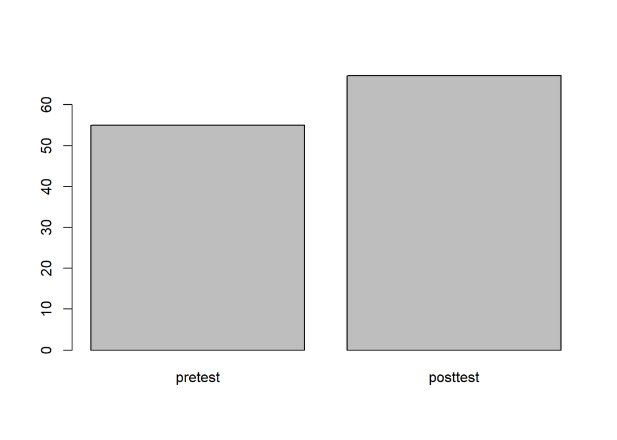

```r
bp = barplot(df.m, ylim = c(0, df.max))
```

```r
bp
```

```
##      [,1]
## [1,]  0.7
## [2,]  1.9
```

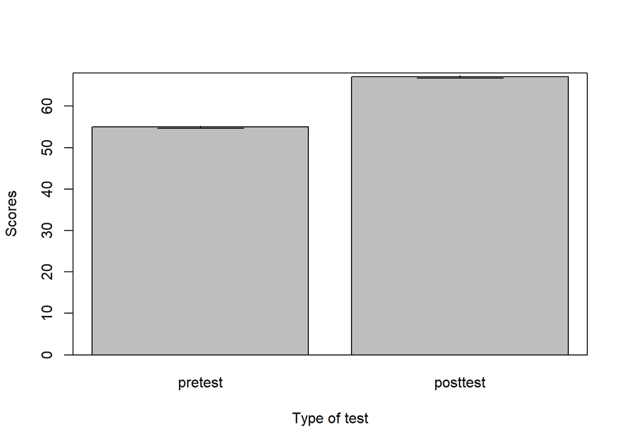

```r
bp = barplot(df.m, ylim = c(0, df.max))
segments(bp, df.m + df.se, bp, df.m - df.se)
segments(bp - 0.2, df.m - df.se, bp + 0.2, df.m - df.se)
box()
title(xlab = 'Type of test', ylab = 'Scores')
```

### Creating Mathematical Expressions

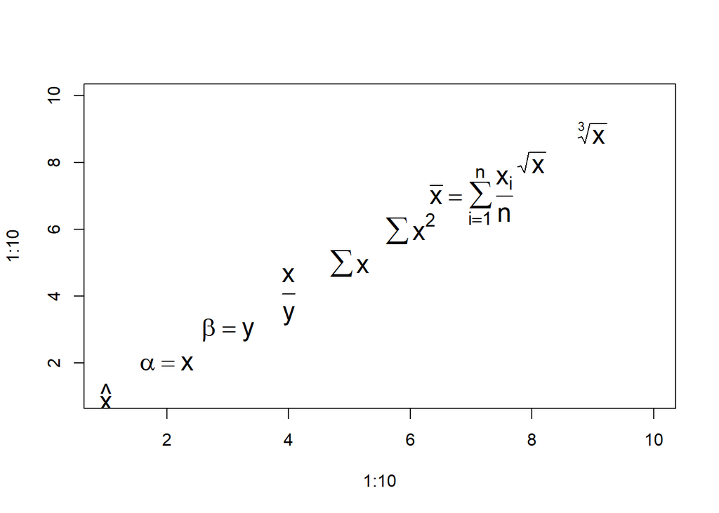

```r
plot(1:10, 1:10, type = 'n')
opt = par(cex = 1.5)
text(1, 1, expression(hat(x)))
text(2, 2, expression(alpha==x))
text(3, 3, expression(beta==y))
text(4, 4, expression(frac(x, y)))
text(5, 5, expression(sum(x)))
text(6, 6, expression(sum(x^2)))
text(7, 7, expression(bar(x) == sum(frac(x[i], n), i==1, n)))
text(8, 8, expression(sqrt(x)))
text(9, 9, expression(sqrt(x, 3)))
```

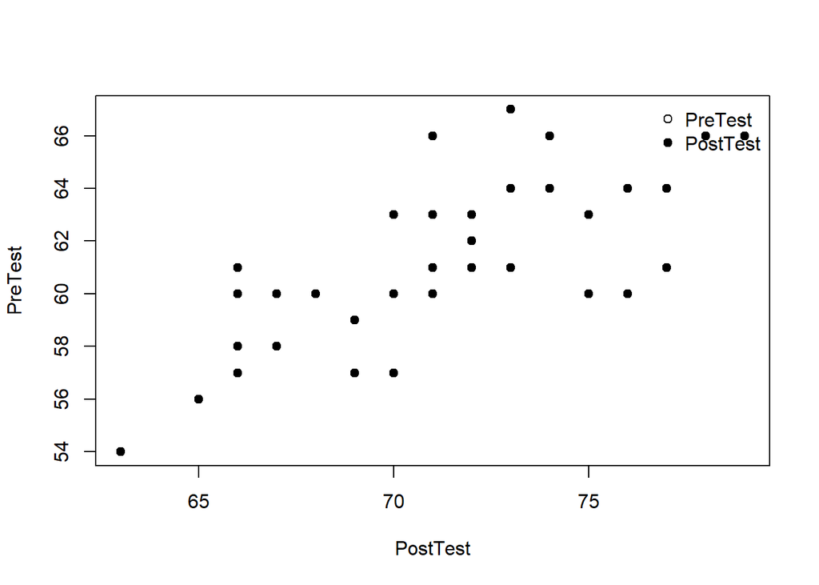

```r
plot(temp$pretest ~ temp$posttest, data = temp, pch = 21, ylab = 'PreTest', xlab = 'PostTest')
points(temp$pretest ~ temp$posttest, data = temp, pch = 19)
legend(x = 'topright', legend = c('PreTest', 'PostTest'), pch = c(21,19), bty =
'n')
```

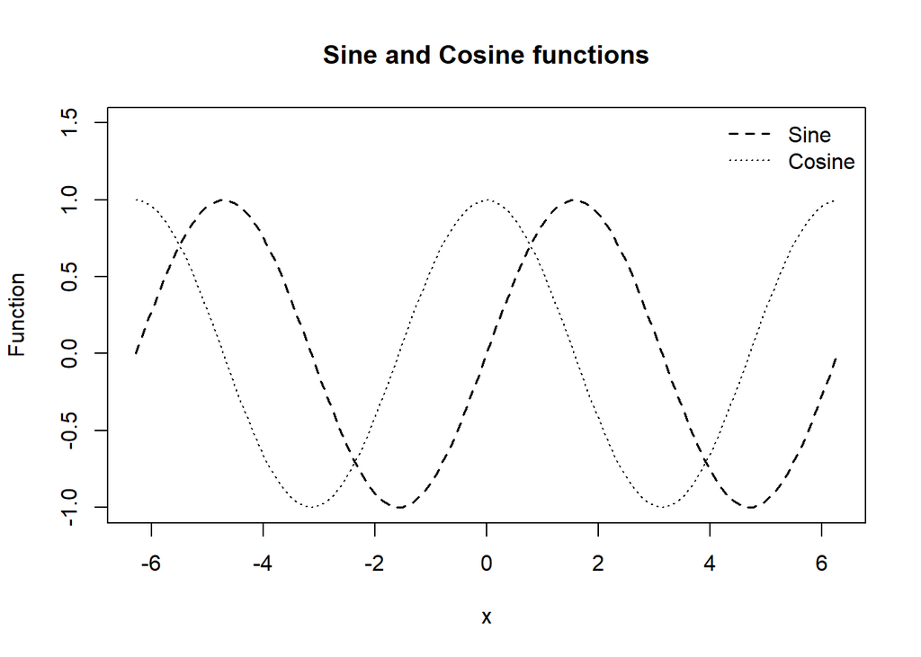

```r
curve(sin, -pi*2, pi*2, lty = 2, lwd = 1.5, ylab = 'Function', ylim = c(-1,1.5))
curve(cos, -pi*2, pi*2, lty = 3, lwd = 1, add = TRUE)
legend(x = 'topright', legend = c('Sine', 'Cosine'), lty = c(2, 3),
lwd = c(1.5, 1), bty = 'n')
title(main = 'Sine and Cosine functions')
```

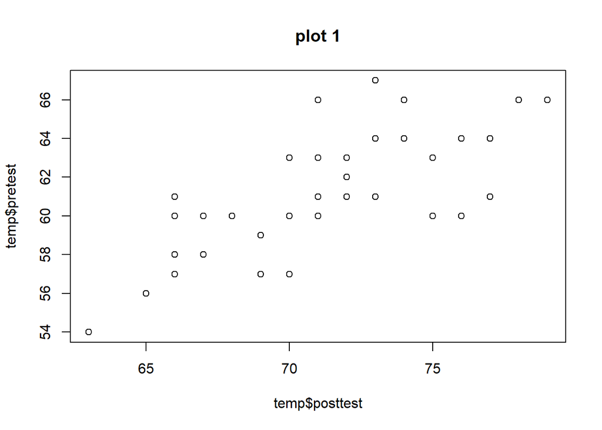

```r
plot(temp$pretest ~ temp$posttest, data = df, main = 'plot 1')
```

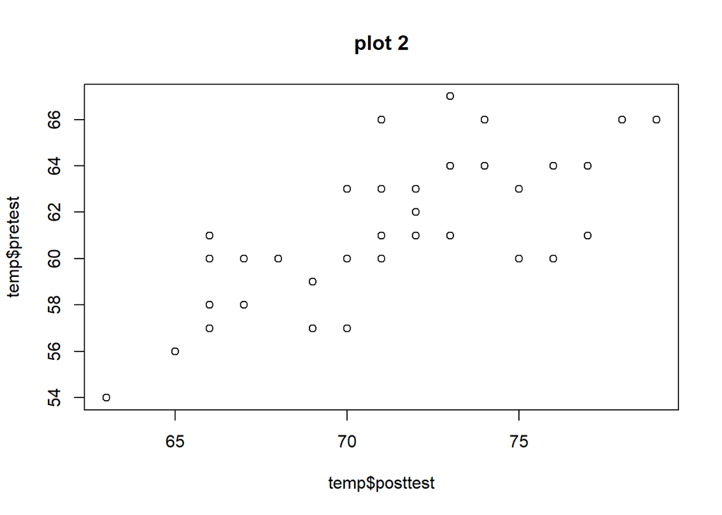

```r
plot(temp$pretest ~ temp$posttest, data = df, main = 'plot 2')
```

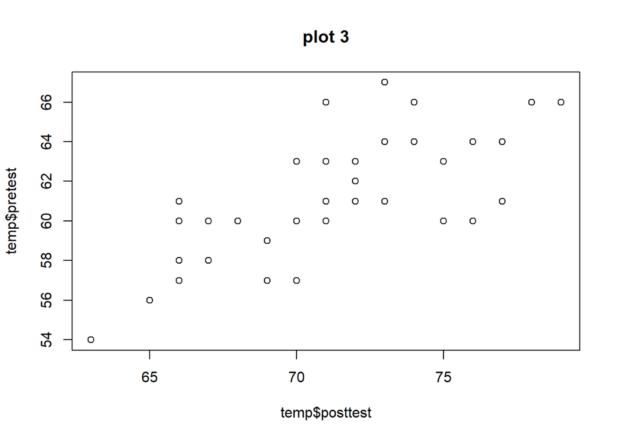

```r
plot(temp$pretest ~ temp$posttest, data = df, main = 'plot 3')
```

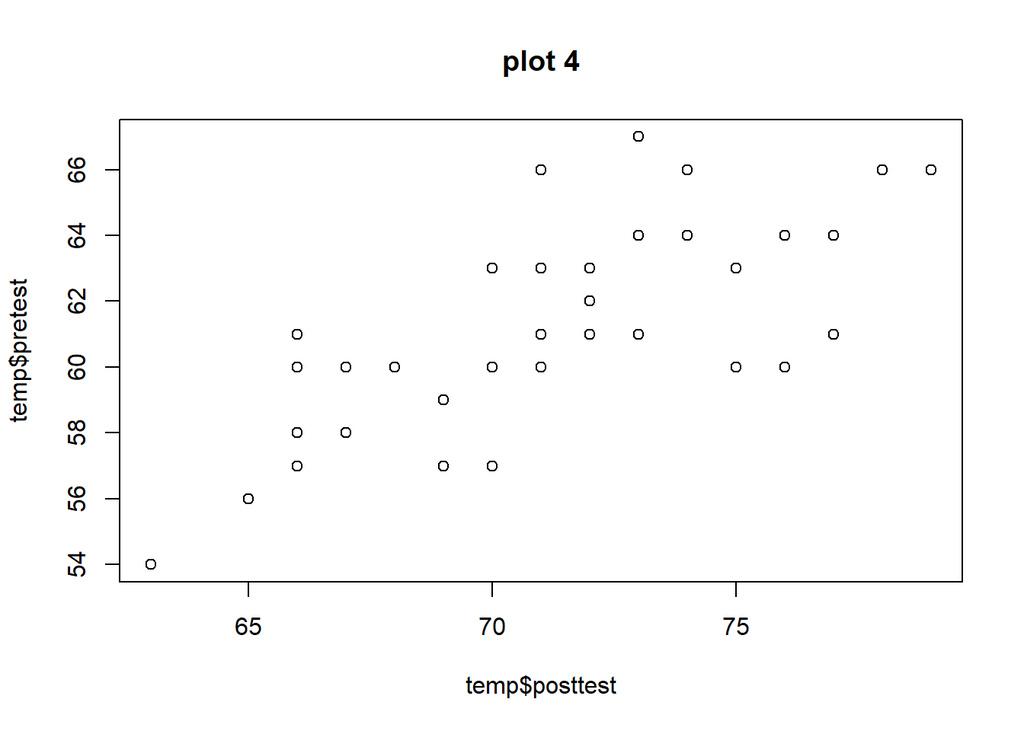

```r
plot(temp$pretest ~ temp$posttest, data = df, main = 'plot 4')
```

```r
par(opt)
```

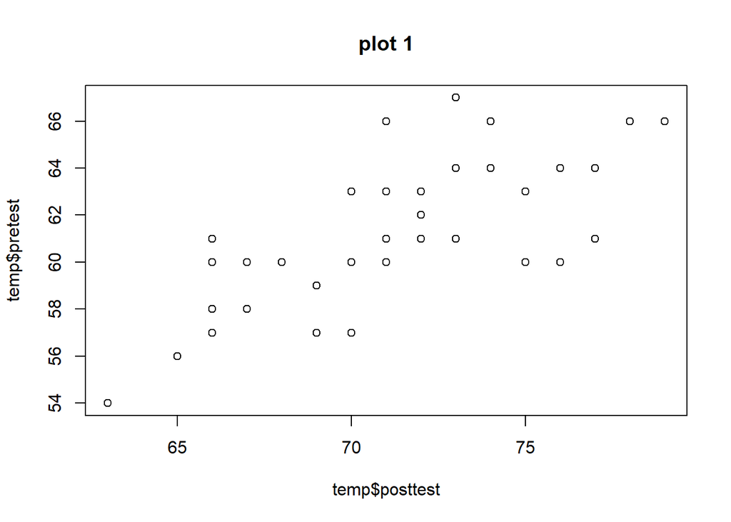

```r
plot(temp$pretest ~ temp$posttest, data = df, main = 'plot 1')
```

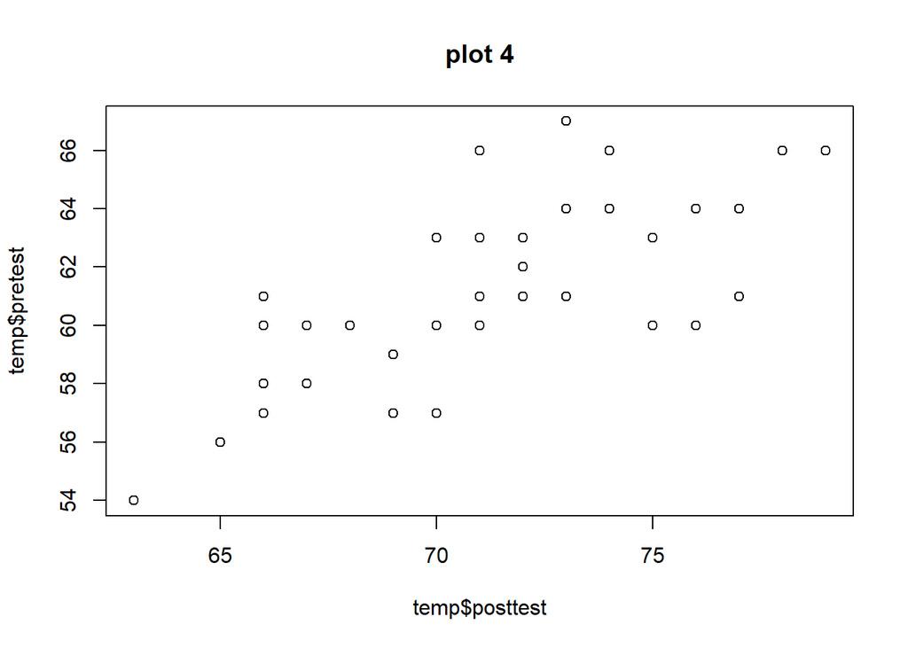

```r
plot.new()
plot.new()
plot(temp$pretest ~ temp$posttest, data = df, main = 'plot 4')
```

```r
par(opt)
```

### Simple customized Functions with multiple lines

```r
cummeadian = function(x) {
tmp = seq_along(x)
for(i in 1:length(tmp)) tmp[i] = median(x[1:i])
print(x)}
```

```r
cummeadian(temp$posttest)
```

```
##  [1] 72 79 76 77 76 74 75 72 77 72 73 74 78 71 77 73 70 73 71 73 68 70 66 70 65
## [26] 67 70 67 63 75 66 71 76 69 69 68 71 66 69 72 66
```

### One-Line Functions

```r
log2 = function(x) log(x, base = 2)
log2
```

```
## function(x) log(x, base = 2)
```

```r
log2(temp$posttest)
```

```
##  [1] 6.169925 6.303781 6.247928 6.266787 6.247928 6.209453 6.228819 6.169925
##  [9] 6.266787 6.169925 6.189825 6.209453 6.285402 6.149747 6.266787 6.189825
## [17] 6.129283 6.189825 6.149747 6.189825 6.087463 6.129283 6.044394 6.129283
## [25] 6.022368 6.066089 6.129283 6.066089 5.977280 6.228819 6.044394 6.149747
## [33] 6.247928 6.108524 6.108524 6.087463 6.149747 6.044394 6.108524 6.169925
## [41] 6.044394
```

### Using Default Values in Functions

```r
manning = function(radius, gradient, coef=0.1125) (radius^(2/3)*gradient^0.5/coef)
```

```r
manning(radius = 1, gradient = 1/500)
```

```
## [1] 0.3975232
```

### Chaining Functions Together with %>%, the Pipe Operator

```r
df %>% filter(df$school == 'ANKYI') %>% summary()
```

```
##     school          school_setting     school_type         classroom
##  Length:41          Length:41          Length:41          Length:41
##  Class :character   Class :character   Class :character   Class :character
##  Mode  :character   Mode  :character   Mode  :character   Mode  :character
##
##
##
##  teaching_method      n_student      student_id           gender
##  Length:41          Min.   :20.00   Length:41          Length:41
##  Class :character   1st Qu.:20.00   Class :character   Class :character
##  Mode  :character   Median :21.00   Mode  :character   Mode  :character
##                     Mean   :20.51
##                     3rd Qu.:21.00
##                     Max.   :21.00
##     lunch              pretest         posttest
##  Length:41          Min.   :54.00   Min.   :63.00
##  Class :character   1st Qu.:60.00   1st Qu.:69.00
##  Mode  :character   Median :61.00   Median :71.00
##                     Mean   :61.34   Mean   :71.39
##                     3rd Qu.:64.00   3rd Qu.:74.00
##                     Max.   :67.00   Max.   :79.00
```

### Without the pipe operator, the preceding code would be written like this:

```r
summary(filter(df, school == 'ANKYI'))
```

```
##     school          school_setting     school_type         classroom
##  Length:41          Length:41          Length:41          Length:41
##  Class :character   Class :character   Class :character   Class :character
##  Mode  :character   Mode  :character   Mode  :character   Mode  :character
##
##
##
##  teaching_method      n_student      student_id           gender
##  Length:41          Min.   :20.00   Length:41          Length:41
##  Class :character   1st Qu.:20.00   Class :character   Class :character
##  Mode  :character   Median :21.00   Mode  :character   Mode  :character
##                     Mean   :20.51
##                     3rd Qu.:21.00
##                     Max.   :21.00
##     lunch              pretest         posttest
##  Length:41          Min.   :54.00   Min.   :63.00
##  Class :character   1st Qu.:60.00   1st Qu.:69.00
##  Mode  :character   Median :61.00   Median :71.00
##                     Mean   :61.34   Mean   :71.39
##                     3rd Qu.:64.00   3rd Qu.:74.00
##                     Max.   :67.00   Max.   :79.00
```

### Creating a Scatter Plot

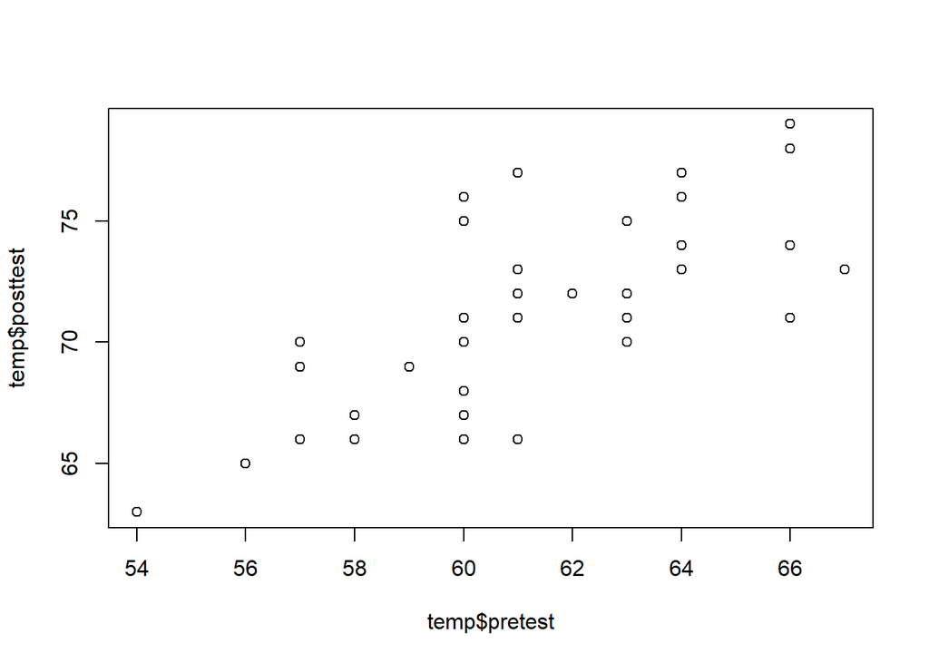

```r
plot(temp$pretest, temp$posttest)
```

### With ggplot2, you can get a similar result using the ggplot() function

```r
library(ggplot2)
```

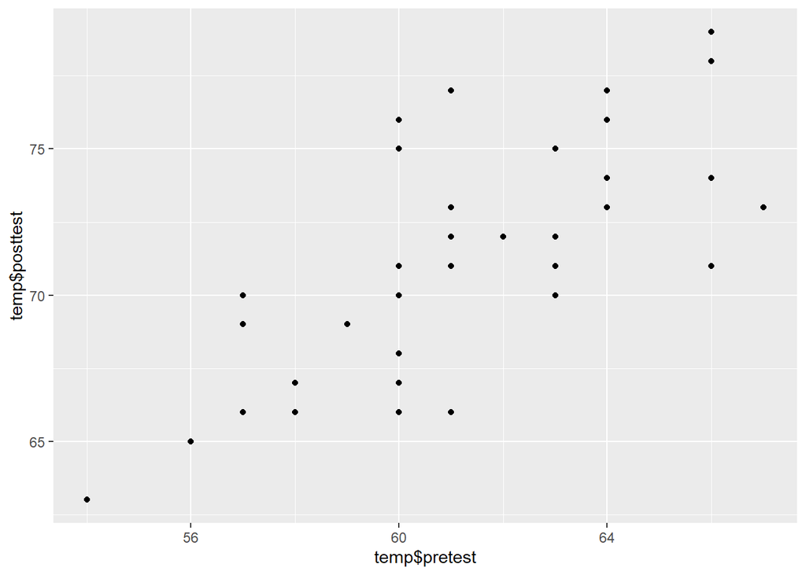

```r
ggplot(temp, aes(x = temp$pretest, y = temp$posttest)) + geom_point()
```

### Creating a Line Graph

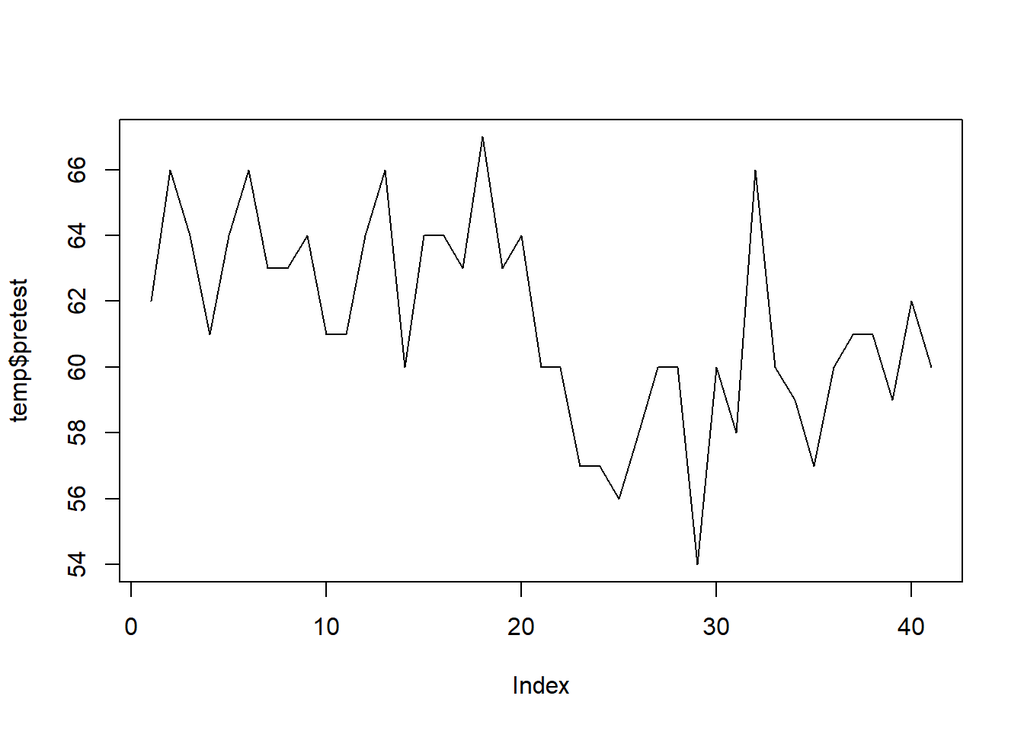

```r
plot(temp$pretest, type = 'l')
```

### With ggplot2

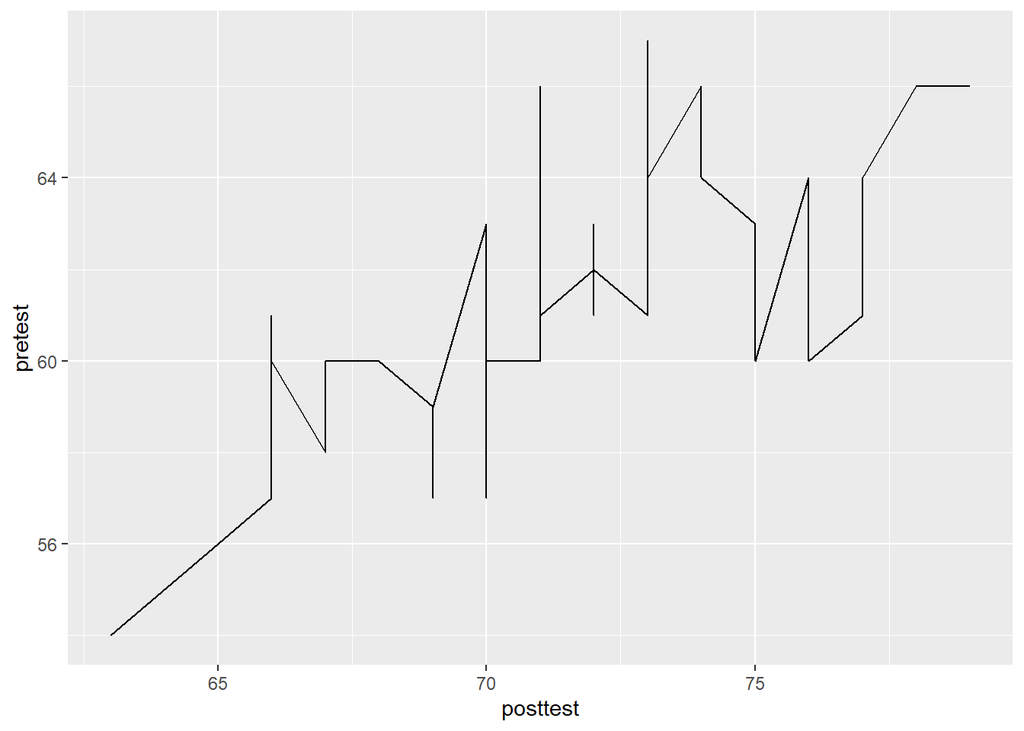

```r
ggplot(temp, aes(x = posttest, y = pretest)) + geom_line()
```

### Creating a Bar Graph

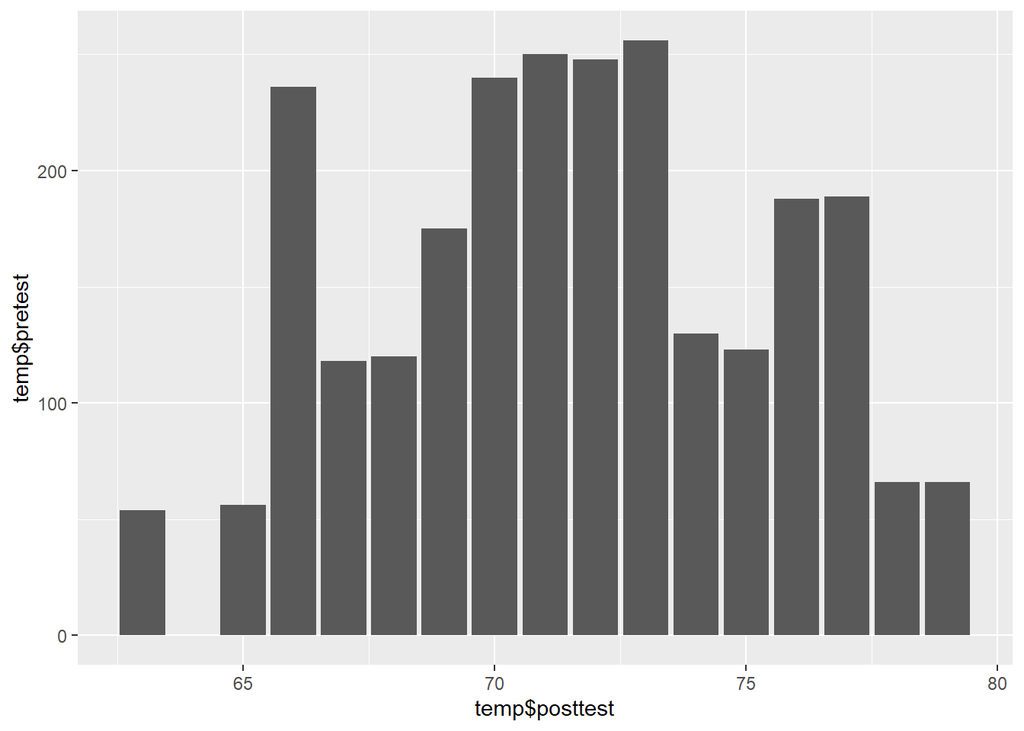

```r
ggplot(temp, aes(x = temp$posttest, y = temp$pretest)) + geom_col()
```

### Creating a Histogram

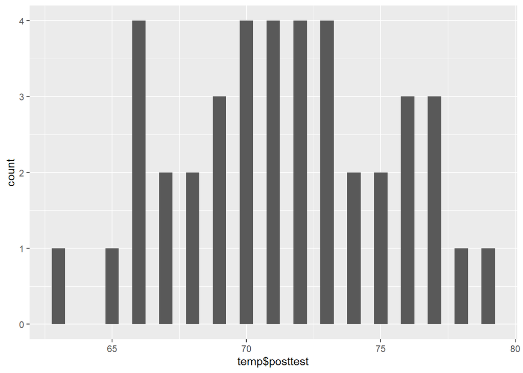

```r
ggplot(temp, aes(x = temp$posttest)) + geom_histogram(binwidth = .5)
```

### Creating a Box Plot

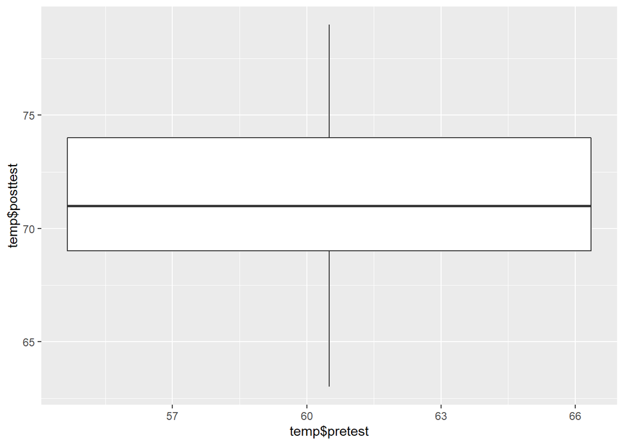

```r
ggplot(temp, aes(x = temp$pretest, y = temp$posttest)) + geom_boxplot()
```

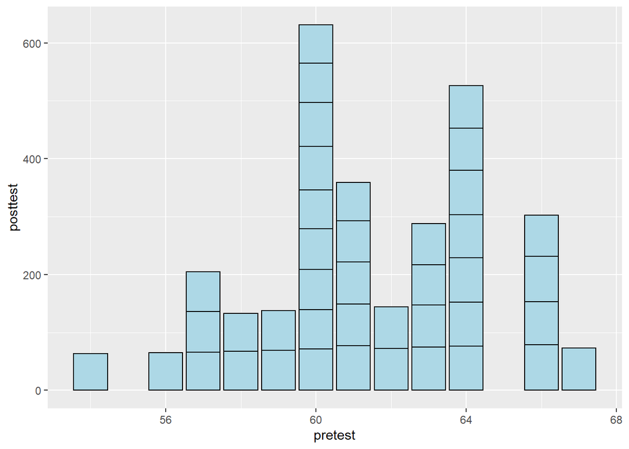

```r
ggplot(temp, aes(x = pretest, y = posttest)) + geom_col(fill = "lightblue", colour = "black")
```

### Grouping Bars Together

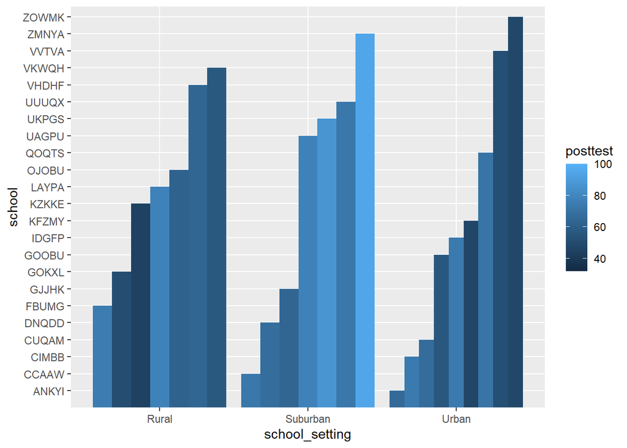

```r
ggplot(df, aes(x = school_setting, y = school, fill = posttest)) + geom_col(position = "dodge")
```

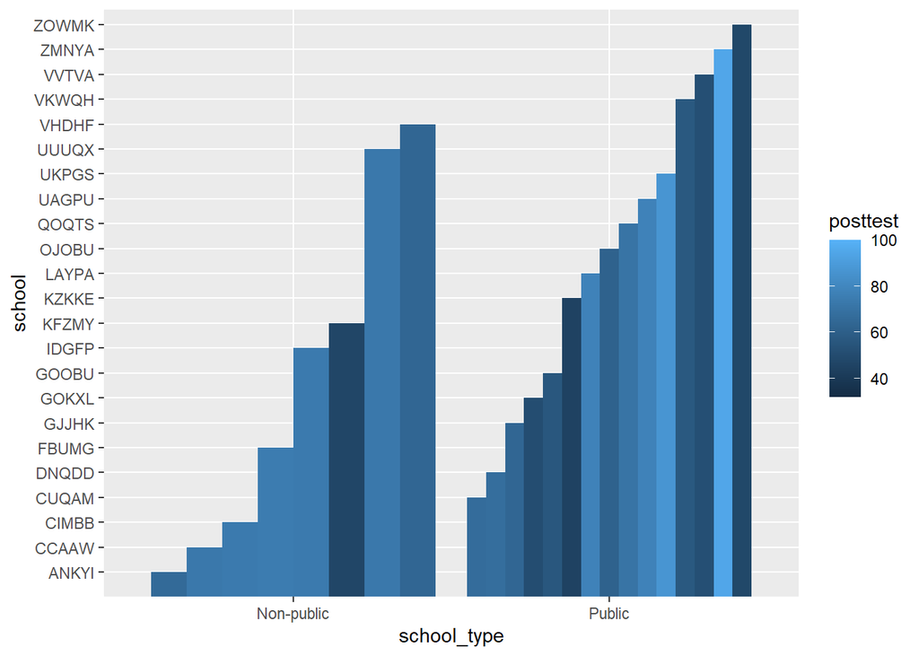

```r
ggplot(df, aes(x = school_type, y = school, fill = posttest)) + geom_col(position = "dodge")
```

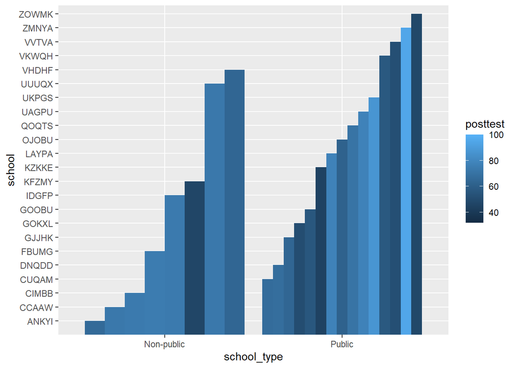

```r
ggplot(df, aes(x = school_type, y = school, fill = posttest)) + geom_col(position = "dodge")
```

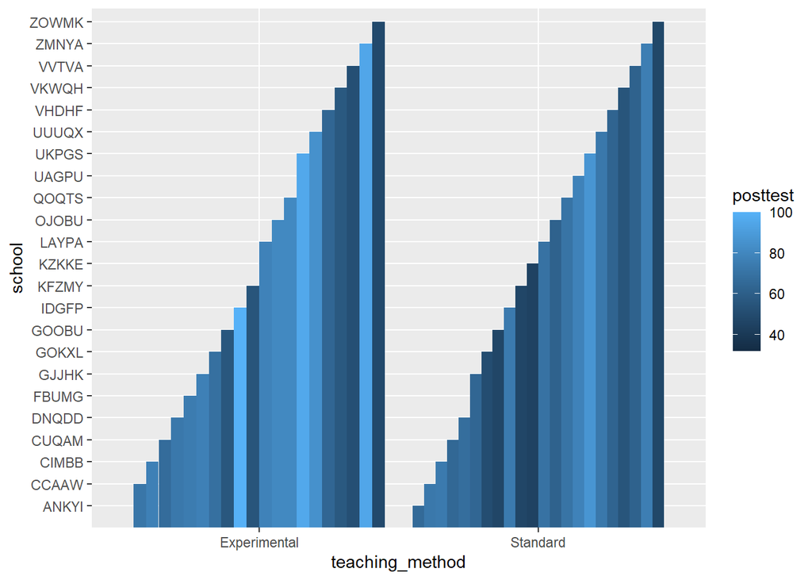

```r
ggplot(df, aes(x = teaching_method, y = school, fill = posttest)) + geom_col(position = "dodge")
```

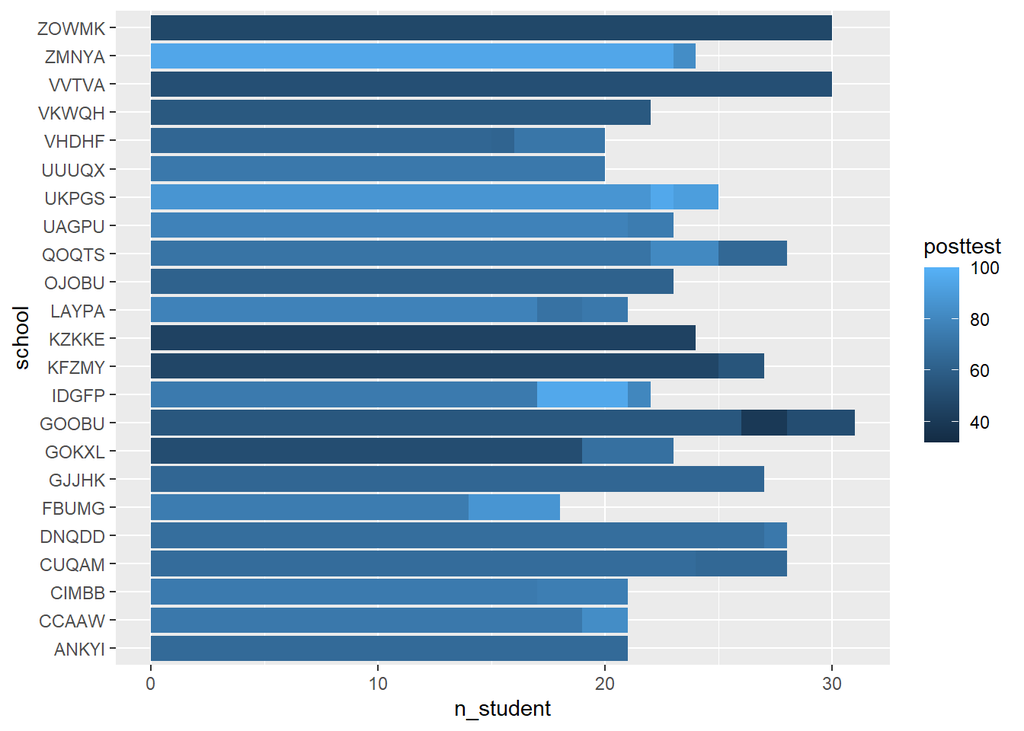

```r
ggplot(df, aes(x = n_student, y = school, fill = posttest)) + geom_col(position = "dodge")
```

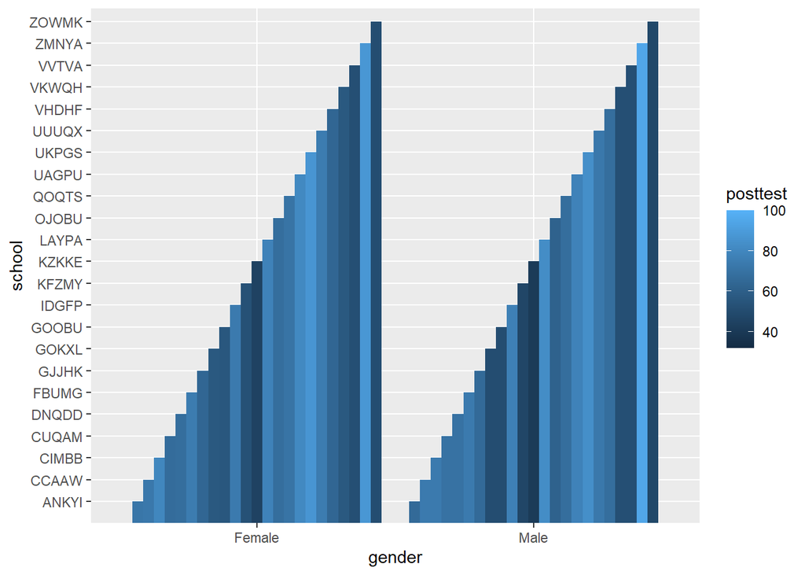

```r
ggplot(df, aes(x = gender, y = school, fill = posttest)) + geom_col(position = "dodge")
```

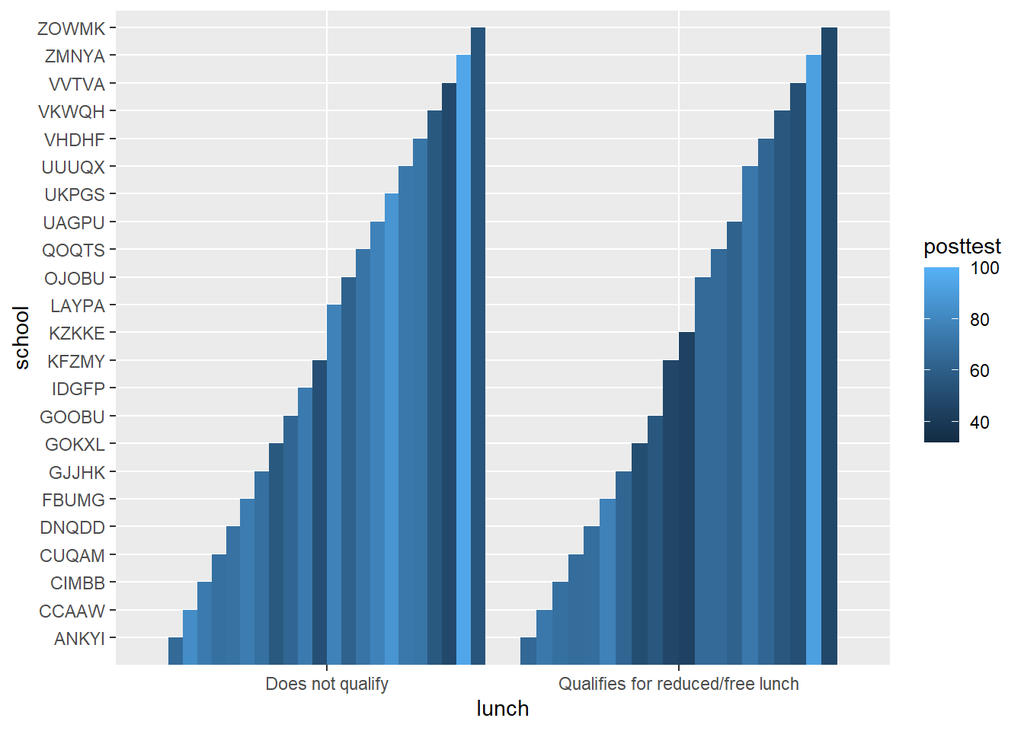

```r
ggplot(df, aes(x = lunch, y = school, fill = posttest)) + geom_col(position = "dodge")
```

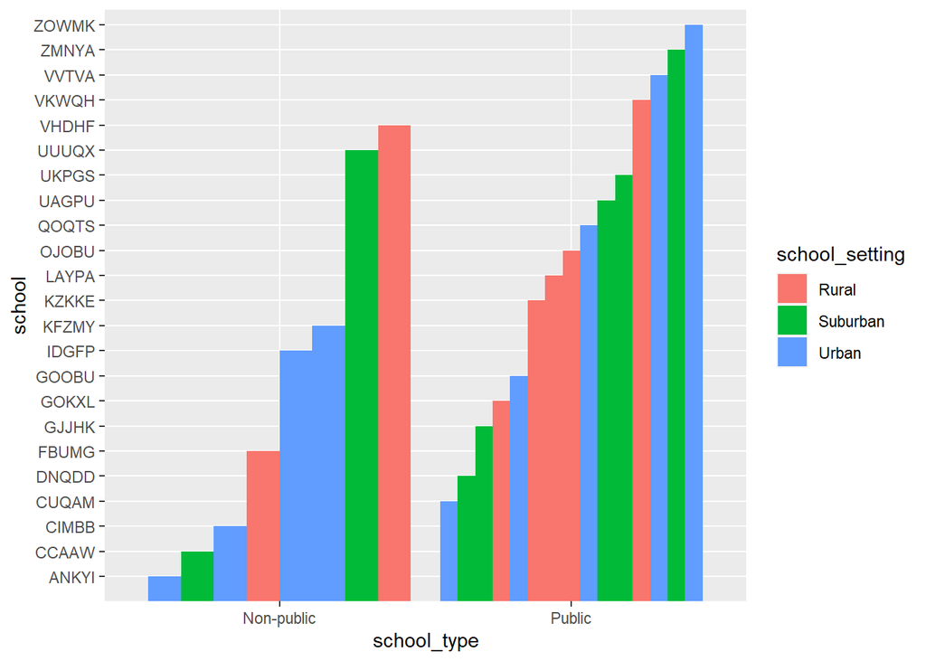

```r
ggplot(df, aes(x = school_type, y = school, fill = school_setting)) + geom_col(position = "dodge")
```

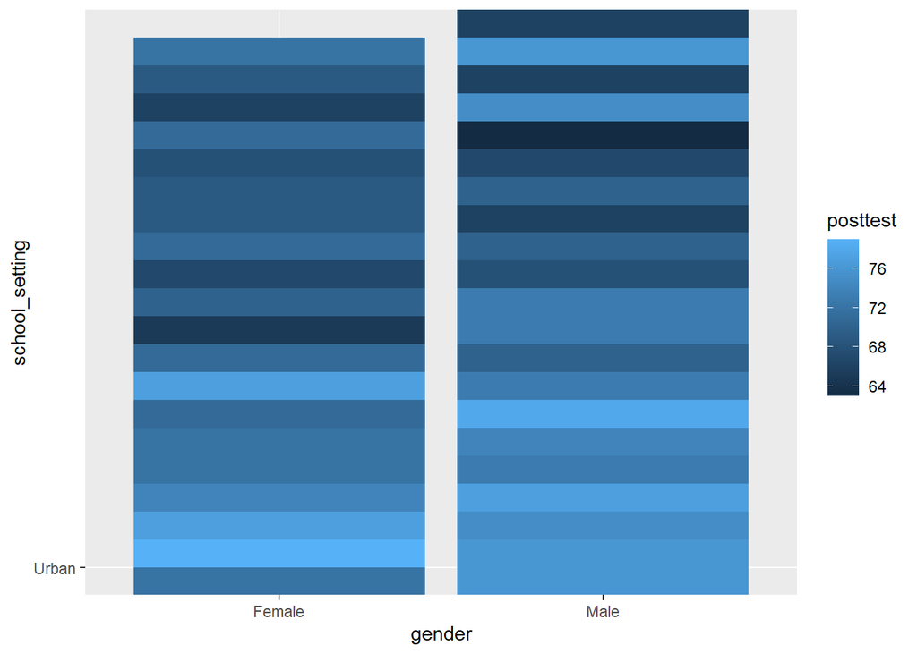

```r
ggplot(temp, aes(x = gender, y = school_setting, fill = posttest)) + geom_col()
```

### Making a Cleveland Dot Plot

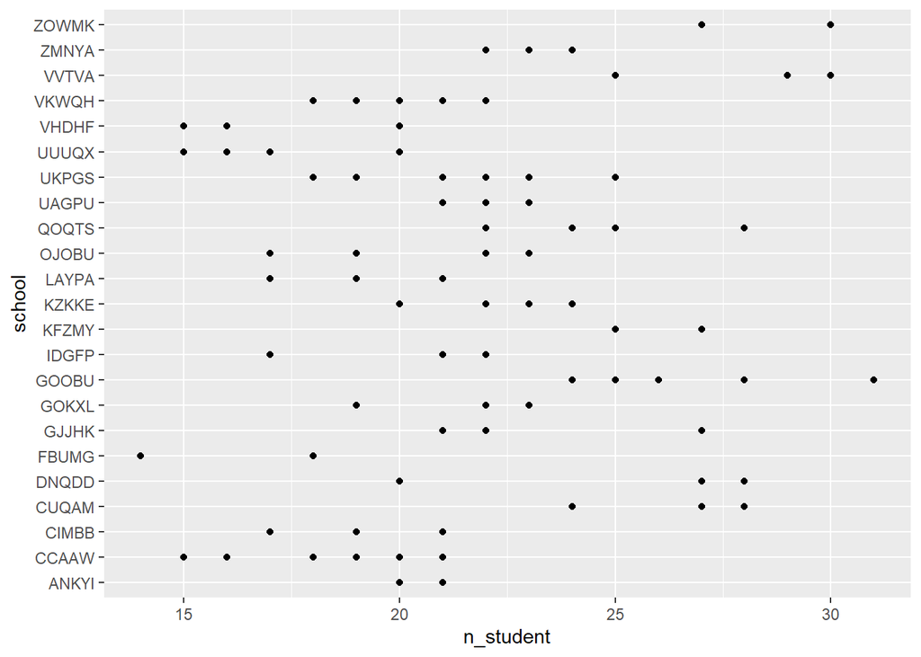

```r
ggplot(df, aes(x = n_student, y = school)) + geom_point()
```

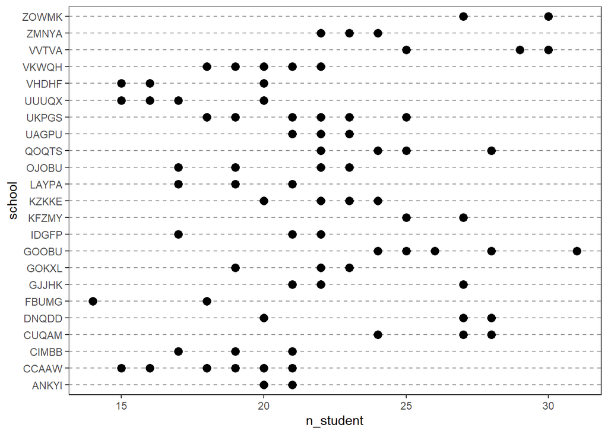

```r
ggplot(df, aes(x = n_student, y = school)) +
 geom_point(size = 3) + # Use a larger dot
 theme_bw() +
 theme(
 panel.grid.major.x = element_blank(),
 panel.grid.minor.x = element_blank(),
 panel.grid.major.y = element_line(colour = "grey60", linetype = "dashed")
 )
```

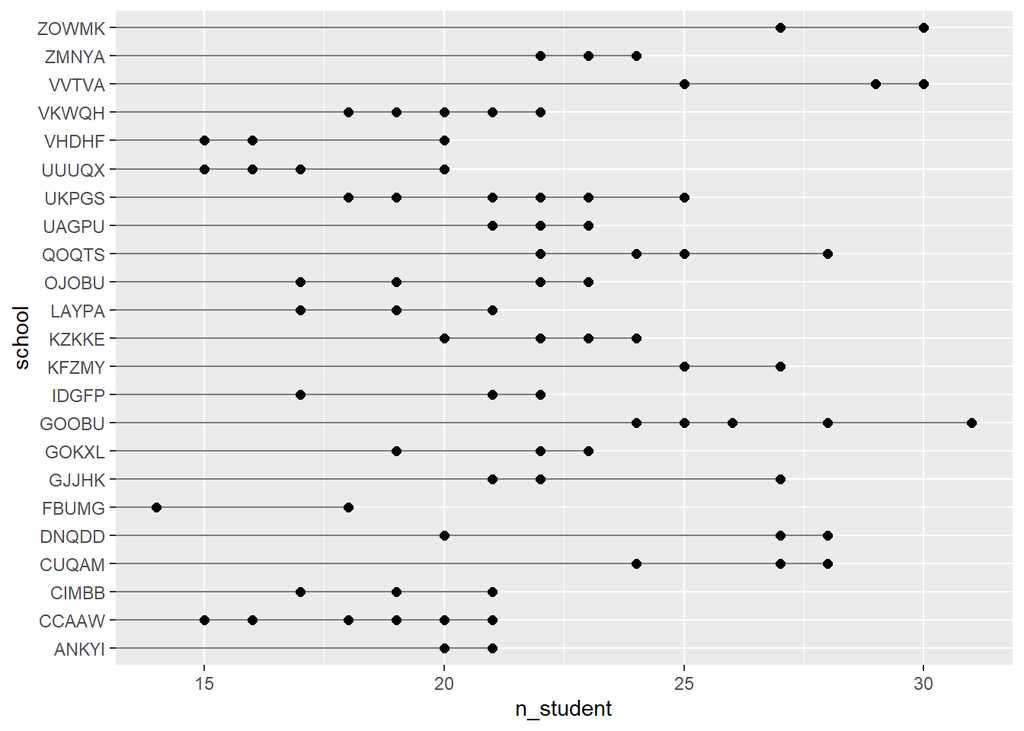

```r
ggplot(df, aes(x = n_student, y = school)) +
geom_segment(aes(yend = school), xend = 0, colour = "grey50") +
  geom_point(size = 2)
```

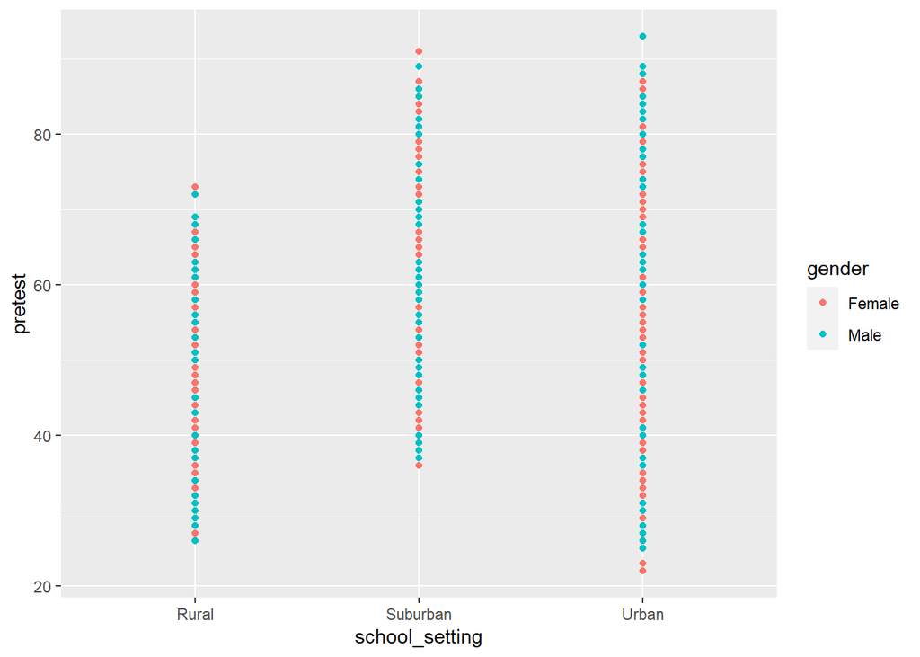

```r
ggplot(df,aes(x=school_setting, y=pretest, colour= gender)) + geom_point()
```

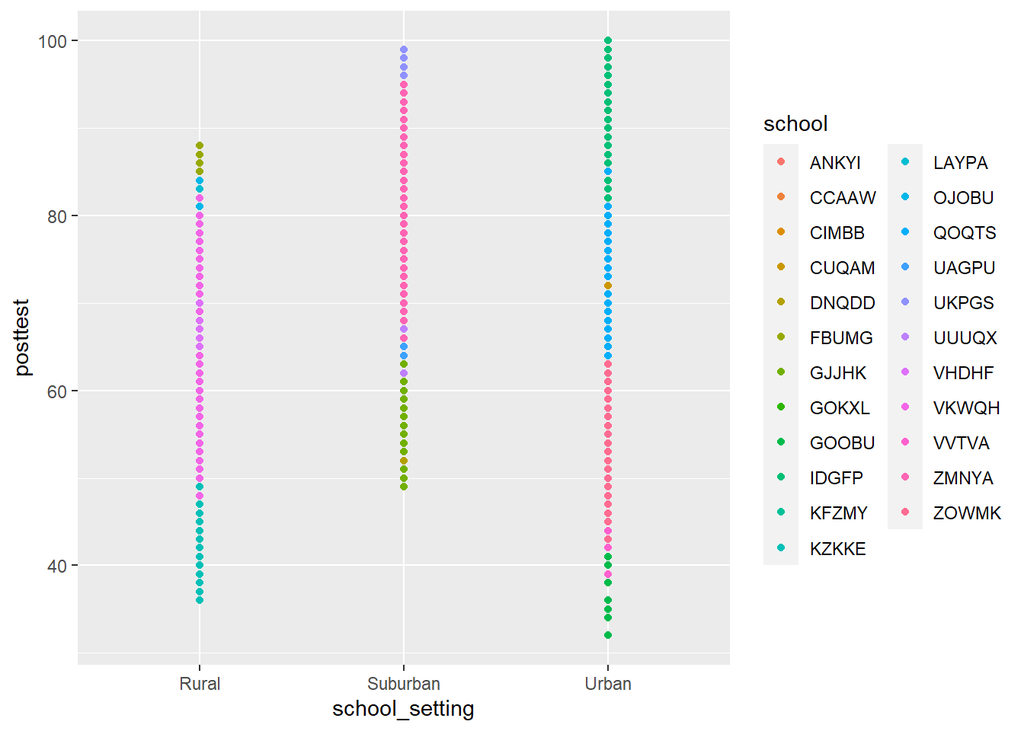

```r
ggplot(df,aes(x=school_setting, y=posttest, colour = school)) + geom_point()
```

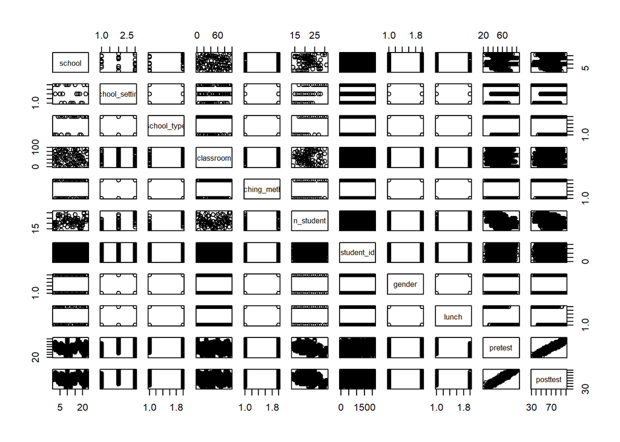

```r
plot(df)
```

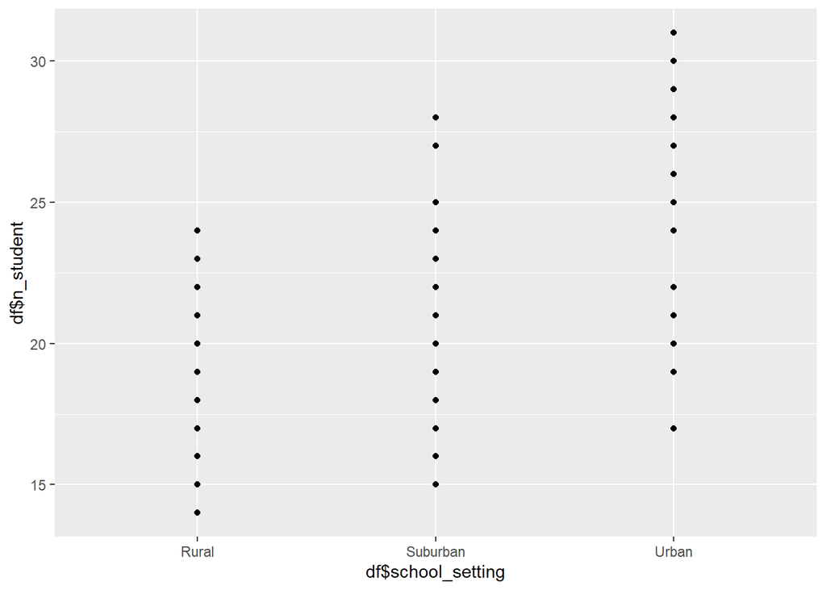

```r
ggplot(df, aes(x = df$school_setting, y = df$n_student)) +
 geom_point(size = 1.5)
```

```r
tt <- df %>%
 filter(df$school_type == 'Public') %>%
 select(school, n_student, pretest, posttest)
head(tt)
```

```
##   school n_student pretest posttest
## 1  CUQAM        28      55       70
## 2  CUQAM        28      55       67
## 3  CUQAM        28      58       70
## 4  CUQAM        28      60       67
## 5  CUQAM        28      58       69
## 6  CUQAM        28      52       63
```

```r
tt = df %>% filter(df$gender == 'Female') %>% select(school, n_student, teaching_method, pretest, posttest)
head(tt)
```

```
##   school n_student teaching_method pretest posttest
## 1  ANKYI        20        Standard      62       72
## 2  ANKYI        20        Standard      66       79
## 3  ANKYI        20        Standard      61       77
## 4  ANKYI        20        Standard      66       74
## 5  ANKYI        20        Standard      63       72
## 6  ANKYI        20        Standard      61       72
```

```r
summary(tt)
```

```
##     school            n_student     teaching_method       pretest
##  Length:1056        Min.   :14.00   Length:1056        Min.   :22.00
##  Class :character   1st Qu.:20.00   Class :character   1st Qu.:43.00
##  Mode  :character   Median :22.00   Mode  :character   Median :55.00
##                     Mean   :22.88                      Mean   :54.87
##                     3rd Qu.:27.00                      3rd Qu.:65.00
##                     Max.   :31.00                      Max.   :91.00
##     posttest
##  Min.   : 32
##  1st Qu.: 56
##  Median : 68
##  Mean   : 67
##  3rd Qu.: 78
##  Max.   :100
```

```r
tt = df %>% filter(df$gender == 'Male') %>% select(school, n_student, teaching_method, pretest, posttest)
head(tt)
```

```
##   school n_student teaching_method pretest posttest
## 1  ANKYI        20        Standard      64       76
## 2  ANKYI        20        Standard      64       76
## 3  ANKYI        20        Standard      63       75
## 4  ANKYI        20        Standard      64       77
## 5  ANKYI        20        Standard      61       73
## 6  ANKYI        20        Standard      64       74
```

```r
summary(tt)
```

```
##     school            n_student     teaching_method       pretest
##  Length:1077        Min.   :14.00   Length:1077        Min.   :25.00
##  Class :character   1st Qu.:20.00   Class :character   1st Qu.:45.00
##  Mode  :character   Median :22.00   Mode  :character   Median :56.00
##                     Mean   :22.72                      Mean   :55.04
##                     3rd Qu.:27.00                      3rd Qu.:64.00
##                     Max.   :31.00                      Max.   :93.00
##     posttest
##  Min.   : 34.0
##  1st Qu.: 57.0
##  Median : 68.0
##  Mean   : 67.2
##  3rd Qu.: 77.0
##  Max.   :100.0
```

```r
tt = df %>% group_by(df$school) %>% summary()
tt
```

```
##     school          school_setting     school_type         classroom
##  Length:2133        Length:2133        Length:2133        Length:2133
##  Class :character   Class :character   Class :character   Class :character
##  Mode  :character   Mode  :character   Mode  :character   Mode  :character
##
##
##
##  teaching_method      n_student     student_id           gender
##  Length:2133        Min.   :14.0   Length:2133        Length:2133
##  Class :character   1st Qu.:20.0   Class :character   Class :character
##  Mode  :character   Median :22.0   Mode  :character   Mode  :character
##                     Mean   :22.8
##                     3rd Qu.:27.0
##                     Max.   :31.0
##     lunch              pretest         posttest      df$school
##  Length:2133        Min.   :22.00   Min.   : 32.0   Length:2133
##  Class :character   1st Qu.:44.00   1st Qu.: 56.0   Class :character
##  Mode  :character   Median :56.00   Median : 68.0   Mode  :character
##                     Mean   :54.96   Mean   : 67.1
##                     3rd Qu.:65.00   3rd Qu.: 77.0
##                     Max.   :93.00   Max.   :100.0
```